# Exploratory2

In this article, I will explore the text file provided by SwiftKey by analyzing the basic statistics and the most frequently used words. Since we have several files with different languages, I will use one file “en_US.Twitter.txt”" as an example for the exploratary analysis. The others should have a similar way for exploration.

First, I set up the directory and load in the data.

```r
# unzip(zipfile="Coursera-SwiftKey.zip")
setwd("~/Desktop/R projects/WordPred/DataSci MileStone Project/final/en_US")
enBlog <- readLines("en_US.blogs.txt")
enNews <- readLines("en_US.news.txt")
enTwitter <- readLines("en_US.twitter.txt")
```

Then, I show the basic statistics of the data with summary which includes linecount. For the word count, I will show it after the cleaning-up of the file.

```r
summary(enBlog)
```

```
##    Length     Class      Mode
##    899288 character character
```

```r
summary(enNews)
```

```
##    Length     Class      Mode
##   1010242 character character
```

```r
summary(enTwitter)
```

```
##    Length     Class      Mode
##   2360148 character character
```

```r
sampleSize <- 5000
enTwitter <- enTwitter[rbinom(sampleSize, length(enTwitter),0.5)]
```

Then, I show the basic statistics of the data with summary which includes linecount and how many lines of tweets have the word “and”.

```r
d <- 'and'
c <- 'and that'
length(enTwitter)
```

```
## [1] 5000
```

```r
#head(enTwitter)
twitter.d <- grep(d,enTwitter)
length(twitter.d)
```

```
## [1] 868
```

```r
twitter <- enTwitter[twitter.d]
length(twitter)
```

```
## [1] 868
```

```r
#head(twitter)
```

```r
summary(doc.corpus)
```

```
## A corpus with 868 text documents
##
## The metadata consists of 2 tag-value pairs and a data frame
## Available tags are:
##   create_date creator
## Available variables in the data frame are:
##   MetaID
```

```r
doc.corpus <- tm_map(doc.corpus, tolower)
doc.corpus <- tm_map(doc.corpus, removePunctuation)
doc.corpus <- tm_map(doc.corpus, removeNumbers)
#doc.corpus <- tm_map(doc.corpus, removeWords,stopwords("english"))
#install.packages("SnowballC")
library(SnowballC)

#doc.corpus <- tm_map(doc.corpus,stemDocument)
doc.corpus <- tm_map(doc.corpus,stripWhitespace)
doc.corpus <- tm_map(doc.corpus,PlainTextDocument)
#inspect(doc.corpus[1])
```

Now I am ready to count the words in the text and find the most frequently used words in the file.

[output not shown]

The most frequently used words and their corresponding frequencies are:

```r
key.terms
```

```
##  [1] "and"  "the"  "to"   "i"    "a"    "you"  "in"   "my"   "of"   "is"
## [11] "for"  "at"   "me"   "on"   "be"   "it"   "have" "with"
```

```r
corpus1.Freq$Freq[corpus1.Freq$Freq>100]
```

```
##  [1] 839 472 398 318 301 224 185 166 158 148 134 130 121 114 110 108 106
## [18] 104
```

Finally I draw a histogram for the words frequency and its summary.

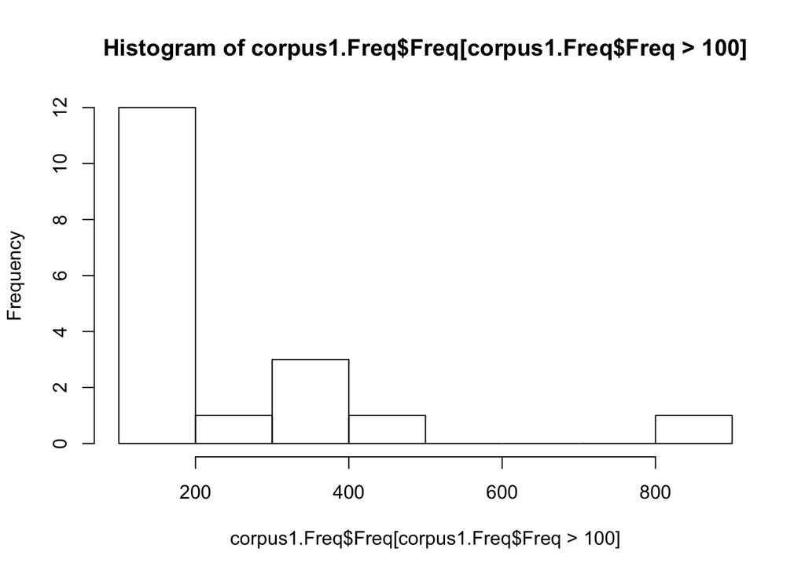

```r
hist(corpus1.Freq$Freq[corpus1.Freq$Freq>100])
```

```r
summary(corpus1.Freq)
```

```
##  corpus1.wrds            Freq
##  Length:2441        Min.   :  1.0
##  Class :character   1st Qu.:  1.0
##  Mode  :character   Median :  2.0
##                     Mean   :  6.2
##                     3rd Qu.:  4.0
##                     Max.   :839.0
```

In the next step, I will creat a probalistic model for the relationship between words. I will explore what are the most used word pairs for each word and rank the frequency of words being used after specific words. After that, I will build a predictive model by using statistical methods inclduing random forests, boosting or decision tree. A temtative approach is shown below.

install.packages(“RWeka”)

options(mc.cores=1)

library(RWeka)

BigramTokenizer <- function(x) {RWeka::NGramTokenizer(x,RWeka::Weka_control(min =2, max =2))}

tdm <- TermDocumentMatrix(doc.corpus, control = list(tokenize = BigramTokenizer))

inspect(tdm[1:3,1:10])

inspect(tdm[rownames(tdm) == c,1:10])

index <- grep(p,rownames(tdm))

temp <- inspect(tdm[index,])

freqMat <- data.frame(apply(temp,1,sum))

words <- rownames(freqMat)[which.max(freqMat[,1])]